# Lab5_Exercises

Melise Edwards

9/28/2020

# Lab 5 Exercises

## **Please Note**

### I was very sick while doing this homework so this is not my best effort. I just didn’t want to fall too far behind so I did the best I could.

## Exercise Number 2 - Revise the above example for joining tables using 6/13/2020 and 9/13/2020. Plot the data as a bar plot. Make sure your graph looks nice in the report by adjusting the height in the R code chunk header.

#### *Note: Exercise Number 1 is a separate link on my main site, follow the link for “Data Visualization Exercises”*

```r
library(tidyverse)
library(dplyr)
```

```r
Confirmed_State_6_13 <-   read_csv(url("https://raw.githubusercontent.com/CSSEGISandData/COVID-19/master/csse_covid_19_data/csse_covid_19_daily_reports/06-13-2020.csv")) %>%
  filter (Country_Region == "US") %>%
  group_by(Province_State, Country_Region) %>%
  summarise(Confirmed = sum(Confirmed))
head(Confirmed_State_6_13)
```

```
## # A tibble: 6 x 3
## # Groups:   Province_State [6]
##   Province_State Country_Region Confirmed
##   <chr>          <chr>              <dbl>
## 1 Alabama        US                 24601
## 2 Alaska         US                   653
## 3 Arizona        US                 34660
## 4 Arkansas       US                 12095
## 5 California     US                150018
## 6 Colorado       US                 29002
```

```r
Confirmed_State_9_13 <-   read_csv(url("https://raw.githubusercontent.com/CSSEGISandData/COVID-19/master/csse_covid_19_data/csse_covid_19_daily_reports/09-13-2020.csv")) %>%
  filter (Country_Region == "US") %>%
  group_by(Province_State, Country_Region) %>%
  summarise(Confirmed = sum(Confirmed))
setdiff(Confirmed_State_9_13$Province_State, Confirmed_State_6_13$Province_State)
```

```
## character(0)
```

```r
Confirmed_State_9_13 <- Confirmed_State_9_13 %>%
  filter(Province_State != "Recovered")
```

```r
Confirmed_State_6_13_9_13_joined <- full_join(Confirmed_State_6_13,
      Confirmed_State_9_13, by = c("Province_State"))

head(Confirmed_State_6_13_9_13_joined) #join the tables
```

```
## # A tibble: 6 x 5
## # Groups:   Province_State [6]
##   Province_State Country_Region.x Confirmed.x Country_Region.y Confirmed.y
##   <chr>          <chr>                  <dbl> <chr>                  <dbl>
## 1 Alabama        US                     24601 US                    138755
## 2 Alaska         US                       653 US                      6268
## 3 Arizona        US                     34660 US                    208512
## 4 Arkansas       US                     12095 US                     70219
## 5 California     US                    150018 US                    761728
## 6 Colorado       US                     29002 US                     61293
```

```r
Confirmed_State_6_13_9_13_joined <- full_join(Confirmed_State_6_13,
      Confirmed_State_9_13, by = c("Province_State")) %>%
      rename(Confirmed_6_13_2020 = "Confirmed.x", Confirmed_9_13_2020 = "Confirmed.y") %>%
      select(-Country_Region.x, -Country_Region.y) %>%
      replace_na(list(Confirmed_6_13_2020 = 0))

head(Confirmed_State_6_13_9_13_joined)
```

```
## # A tibble: 6 x 3
## # Groups:   Province_State [6]
##   Province_State Confirmed_6_13_2020 Confirmed_9_13_2020
##   <chr>                        <dbl>               <dbl>
## 1 Alabama                      24601              138755
## 2 Alaska                         653                6268
## 3 Arizona                      34660              208512
## 4 Arkansas                     12095               70219
## 5 California                  150018              761728
## 6 Colorado                     29002               61293
```

## Switching between wide and long table formats.

```r
Confirmed_State_6_13_9_13_joined_long <- Confirmed_State_6_13_9_13_joined %>%
              pivot_longer(-c(Province_State),
                            names_to = "Date", values_to = "Confirmed")
head(Confirmed_State_6_13_9_13_joined_long)
```

```
## # A tibble: 6 x 3
## # Groups:   Province_State [3]
##   Province_State Date                Confirmed
##   <chr>          <chr>                   <dbl>
## 1 Alabama        Confirmed_6_13_2020     24601
## 2 Alabama        Confirmed_9_13_2020    138755
## 3 Alaska         Confirmed_6_13_2020       653
## 4 Alaska         Confirmed_9_13_2020      6268
## 5 Arizona        Confirmed_6_13_2020     34660
## 6 Arizona        Confirmed_9_13_2020    208512
```

## Exercise number 3 - Add more informative x and y labels and a title to the above graph in Ex2.

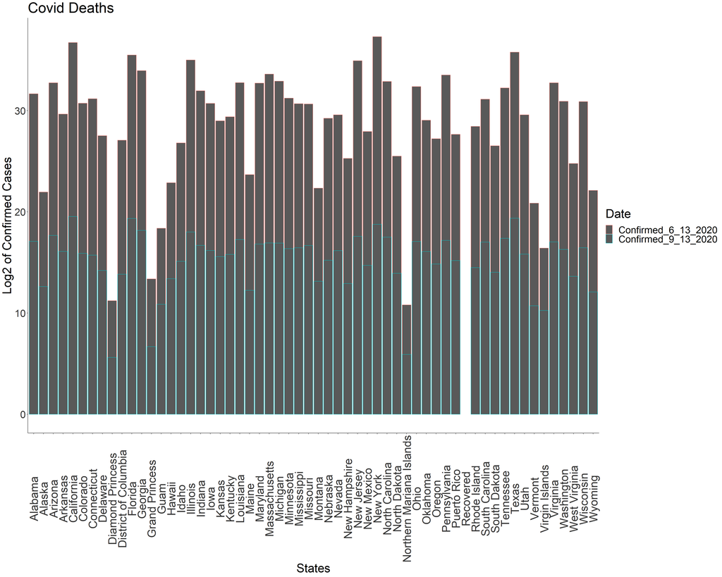

```r
# to adjust figure size {r, fig.width = 5, fig.height = 10}

ggplot(na.omit(Confirmed_State_6_13_9_13_joined_long),
       aes(x = Province_State, y = log2(Confirmed)))  +
    geom_bar(aes(color = Date), position="stack", stat="identity") +
  theme_classic() +
  theme(axis.text.x = element_text(colour = "grey20", size = 28, angle = 90, hjust = 0.5, vjust = 0.5),
                        axis.text.y = element_text(colour = "grey20", size = 25),
        text = element_text(size = 30)) +
  labs(title = "Covid Deaths",
       x = "States",
       y = "Log2 of Confirmed Cases")
```

```r
?labs
```

```
## starting httpd help server ... done
```

## Exercise number 4 - Using the time series data. Make a plot of the total number of confirmed deaths per day worldwide

```r
time_series_confirmed <- read_csv(url("https://raw.githubusercontent.com/CSSEGISandData/COVID-19/master/csse_covid_19_data/csse_covid_19_time_series/time_series_covid19_confirmed_global.csv")) %>%
  rename(Province_State = "Province/State", Country_Region = "Country/Region")
time_series_deaths <- read_csv("data/time_series_covid19_deaths_global.csv")%>%
  rename(Province_State = "Province/State", Country_Region = "Country/Region")
time_series_deaths_long <- time_series_deaths %>%
               pivot_longer(-c(Province_State, Country_Region, Lat, Long),
                            names_to = "Date", values_to = "Deaths")
```

```r
time_series_confirmed_long <- time_series_confirmed %>%
               pivot_longer(-c(Province_State, Country_Region, Lat, Long),
                            names_to = "Date", values_to = "Confirmed")

time_series_confirmed_long <- time_series_confirmed_long %>%
  unite(Key, Province_State, Country_Region, Date, sep = ".", remove = FALSE)
```

```r
time_series_confirmed_long <- time_series_confirmed_long %>%
  unite(Key, Province_State, Country_Region, Date, sep = ".", remove = FALSE)
```

```r
head(time_series_confirmed_long)
```

```
## # A tibble: 6 x 7
##   Province_State Key                 Country_Region   Lat  Long Date   Confirmed
##   <chr>          <chr>               <chr>          <dbl> <dbl> <chr>      <dbl>
## 1 <NA>           NA.Afghanistan.1/2~ Afghanistan     33.9  67.7 1/22/~         0
## 2 <NA>           NA.Afghanistan.1/2~ Afghanistan     33.9  67.7 1/23/~         0
## 3 <NA>           NA.Afghanistan.1/2~ Afghanistan     33.9  67.7 1/24/~         0
## 4 <NA>           NA.Afghanistan.1/2~ Afghanistan     33.9  67.7 1/25/~         0
## 5 <NA>           NA.Afghanistan.1/2~ Afghanistan     33.9  67.7 1/26/~         0
## 6 <NA>           NA.Afghanistan.1/2~ Afghanistan     33.9  67.7 1/27/~         0
```

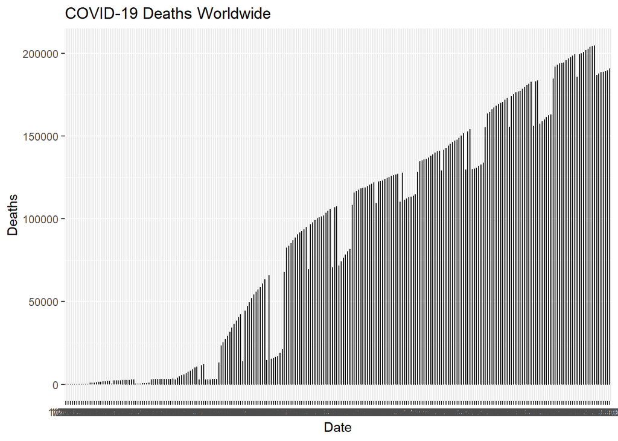

```r
time_series_deaths_long %>%
  group_by(Country_Region, Date) %>%
  summarise(Deaths = sum(Deaths)) %>%
ggplot(aes(x = Date,  y = Deaths)) +
    geom_line() +
    ggtitle("COVID-19 Deaths Worldwide")
```

Need to come back to this later….

## Exercise number 5 - Use Mutate to make a new column with deaths/confirmed cases (Hint: this might be best done after joining the tables, but before pivoting longer).

```r
# so basically need to take time series and confirmed pre-long and join, then pivot long, then mutate to make new column. ugh
confirmed <- time_series_confirmed_long %>%
  select(Confirmed)

time_series_deaths_long_joined <- cbind(time_series_deaths_long, confirmed)
head(time_series_deaths_long_joined)
```

```
##   Province_State Country_Region      Lat     Long    Date Deaths Confirmed
## 1           <NA>    Afghanistan 33.93911 67.70995 1/22/20      0         0
## 2           <NA>    Afghanistan 33.93911 67.70995 1/23/20      0         0
## 3           <NA>    Afghanistan 33.93911 67.70995 1/24/20      0         0
## 4           <NA>    Afghanistan 33.93911 67.70995 1/25/20      0         0
## 5           <NA>    Afghanistan 33.93911 67.70995 1/26/20      0         0
## 6           <NA>    Afghanistan 33.93911 67.70995 1/27/20      0         0
```

```r
time_series_deaths_new_column <- time_series_deaths_long_joined %>%
  mutate(Deaths_Confirmed = Deaths/Confirmed)
head(time_series_deaths_new_column)
```

```
##   Province_State Country_Region      Lat     Long    Date Deaths Confirmed
## 1           <NA>    Afghanistan 33.93911 67.70995 1/22/20      0         0
## 2           <NA>    Afghanistan 33.93911 67.70995 1/23/20      0         0
## 3           <NA>    Afghanistan 33.93911 67.70995 1/24/20      0         0
## 4           <NA>    Afghanistan 33.93911 67.70995 1/25/20      0         0
## 5           <NA>    Afghanistan 33.93911 67.70995 1/26/20      0         0
## 6           <NA>    Afghanistan 33.93911 67.70995 1/27/20      0         0
##   Deaths_Confirmed
## 1              NaN
## 2              NaN
## 3              NaN
## 4              NaN
## 5              NaN
## 6              NaN
```

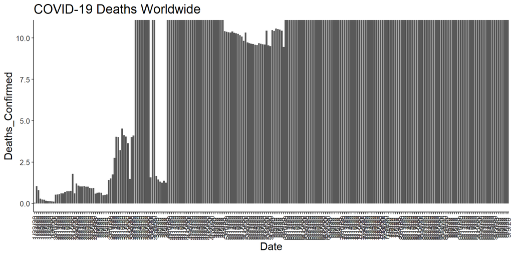

```r
time_series_deaths_new_column %>%
  filter(!is.na(Deaths_Confirmed)) %>%
  group_by(Date) %>%
ggplot(aes(x = Date,  y = Deaths_Confirmed)) +
    geom_bar(stat = "identity") +
    ggtitle("COVID-19 Deaths Worldwide") +
  theme_classic() +
  theme(axis.text.x = element_text(colour = "grey20", size = 10, angle = 90, hjust = 0.5, vjust = 0.5),
                        axis.text.y = element_text(colour = "grey20", size = 10),
        text = element_text(size = 15))
```

## Exercise 7 - Make a single graph with from the times series data with the 10 countries with the hightest death total.

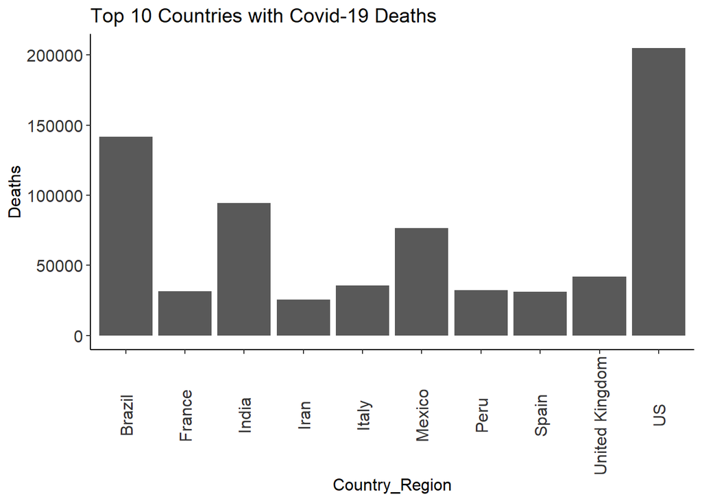

```r
top.10.countries <- time_series_deaths_long %>%
  group_by(Country_Region,Deaths, Date) %>%
  select(Country_Region, Deaths, Date) %>%
  arrange(desc(Deaths)) %>%
  filter(Date == '9/27/20')

top.10.countries[1:10,] %>%
  ggplot(aes(x = Country_Region, y = Deaths)) +
  geom_bar(stat = "identity") +
  theme_classic() +
  theme(axis.text.x = element_text(colour = "grey20", size = 12, angle = 90, hjust = 0.5, vjust = 0.5),
                        axis.text.y = element_text(colour = "grey20", size = 12),
        text = element_text(size = 12)) +
  ggtitle("Top 10 Countries with Covid-19 Deaths")
```

## Exercise 8 - Using Facet_Wraps make a graph from the times series data with the 10 countries with the hightest death total. Format the table to look nice in the report by changing the number of rows in your graph and/or adjusting the height in the R code chunk header.

```r
topten <- time_series_deaths_long %>%
  group_by(Date) %>%
  arrange(desc(Deaths))


topten
```

```
## # A tibble: 66,500 x 6
## # Groups:   Date [250]
##    Province_State Country_Region   Lat  Long Date    Deaths
##    <chr>          <chr>          <dbl> <dbl> <chr>    <dbl>
##  1 <NA>           US                40  -100 9/27/20 204756
##  2 <NA>           US                40  -100 9/26/20 204490
##  3 <NA>           US                40  -100 9/25/20 203750
##  4 <NA>           US                40  -100 9/24/20 202798
##  5 <NA>           US                40  -100 9/23/20 201884
##  6 <NA>           US                40  -100 9/22/20 200786
##  7 <NA>           US                40  -100 9/21/20 199865
##  8 <NA>           US                40  -100 9/20/20 199509
##  9 <NA>           US                40  -100 9/19/20 199282
## 10 <NA>           US                40  -100 9/18/20 198570
## # ... with 66,490 more rows
```

[output not shown]

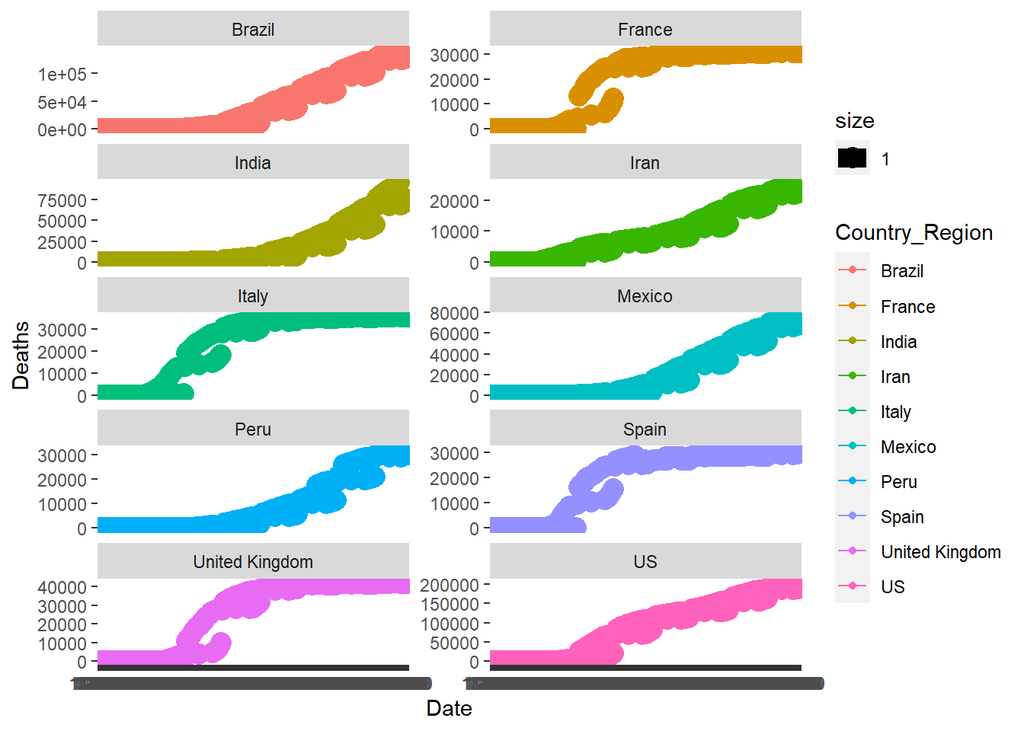

```r
time_series_deaths_long %>%
  group_by(Country_Region, Date) %>%
  summarise_at(c("Deaths"), sum) %>%
  filter (Country_Region %in% c("Brazil",
                              "France",
                             "India",
                             "Iran",
                             "Italy",
                             "Mexico",
                             "Peru",
                             "Spain",
                             "United Kingdom",
                             "US")) %>%
  ggplot(aes(x = Date, y = Deaths, color = Country_Region, size = 1)) +
  geom_point() +
  geom_line()+
  facet_wrap(~Country_Region, ncol=2, scales="free_y")
```

```r
 #unsure what the problem is but cant spend any more time working on this
```

## Exercise 9

```r
time_series_covid19_confirmed_US <- read_csv(url("https://raw.githubusercontent.com/CSSEGISandData/COVID-19/master/csse_covid_19_data/csse_covid_19_time_series/time_series_covid19_confirmed_US.csv")) %>%
  group_by(Province_State) %>%
  select(-c(UID, iso2, iso3, code3, FIPS, Admin2, Lat, Long_, Combined_Key, Country_Region)) %>%
  pivot_longer(-c(Province_State), names_to = "Date", values_to = "Confirmed") %>%
  group_by(Province_State, Date) %>%
  summarise(Confirmed = sum(Confirmed))
?summarise_each
```

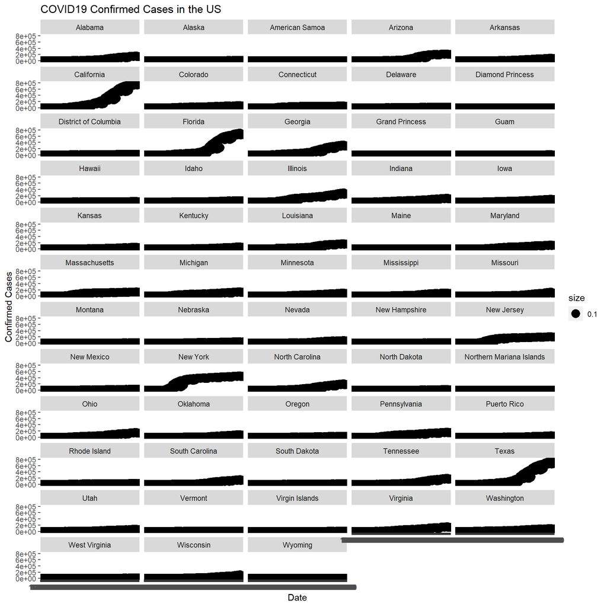

```r
time_series_covid19_confirmed_US %>%
  ggplot(aes(x = Date, y = Confirmed, size = 0.1)) +
  geom_point()+
  facet_wrap('Province_State', ncol = 5) +
  labs(x = "Date",
       y = "Confirmed Cases",
       title = "COVID19 Confirmed Cases in the US")
```

## Exercise 10 - Apply a theme other than the one used in the Data Carpentries tutorial to the graph in Ex8.

[output not shown]

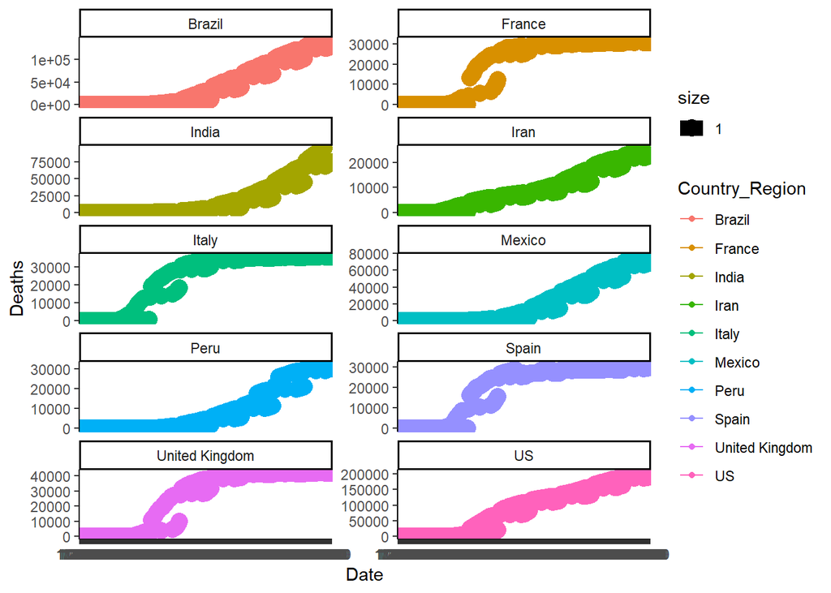

```r
time_series_deaths_long %>%
  group_by(Country_Region, Date) %>%
  summarise_at(c("Deaths"), sum) %>%
  filter (Country_Region %in% c("Brazil",
                              "France",
                             "India",
                             "Iran",
                             "Italy",
                             "Mexico",
                             "Peru",
                             "Spain",
                             "United Kingdom",
                             "US")) %>%
  ggplot(aes(x = Date, y = Deaths, color = Country_Region, size = 1)) +
  geom_point() +
  geom_line()+
  facet_wrap(~Country_Region, ncol=2, scales="free_y") +
  theme_classic()
```